# Python-from-Scratch

## 关于Python

### Python简介

Python是一种被广泛使用的高级编程语言，它的设计理念强调代码可读性，同时其语言也具有简洁性，允许程序员用更少的代码来表达概念。Python支持多种编程范式，包括面向对象的、命令式、函数式编程或面向过程的编程。它具有庞大而全面的标准库，可以轻易完成各种高级任务。

### 下载与安装

目前Python有两个版本，一个是2.x版，一个是3.x版，且两个版本不兼容。由于3.x版越来越普及，所以本教程将以最新版本Python3.7为基础。

在Linux上，通常默认安装Python；

在Mac系统上，如果系统自带不是3.7版本，可从Python官网下载安装；（https://www.python.org/）

在Windows系统上，建议安装Anaconda，它是一个开源的Python发行版本。（https://www.anaconda.com/）

### 运行Python

Python安装成功后，打开命令提示符窗口，输入python后，看到提示符变为“>>>”就表示我们已经在Python交互式环境中了，可以输入任何Python代码，回车后会立刻得到执行结果。

输入exit()并回车，可以退出Python交互式环境（直接关掉命令行窗口也可以）。

## 基本运算

```python
5 + 2
```

```
7
```

```python
5 - 2
```

```
3
```

```python
5 * 2
```

```
10
```

```python
5 ** 2  #幂
```

```
25
```

注意：在Python中符号(^)的用法不再是求幂，而是“异或”,用于逻辑运算。

```python
5 ^ 2
```

```
7
```

```python
5 / 2  #注意：两个整型数相除的结果是实型
```

```
2.5
```

```python
5 // 2  #地板除，即只取结果的整数部分
```

```
2
```

```python
5 % 2  #取余
```

```
1
```

```python
_ + 3  #在Python中，"_"可用于调用上次的结果
```

```
4
```

## 数据类型

### 字符串

```python
a = "Li Feng"
a
```

```
'Li Feng'
```

```python
type(a)  #type()用于求数据类型
```

```
str
```

```python
len(a)   #len()用于求字符串包含多少个字符
```

```
7
```

```python
a = "Li Feng"
a[0]  #索引从0开始
```

```
'L'
```

```python
a[-2]  #负号表示倒数，即从右往左数
```

```
'n'
```

```python
a[3:5]  #[3:5]处理为[3,5)
```

```
'Fe'
```

```python
a[3:100]  #超出索引的部分忽略
```

```
'Feng'
```

```python
a[3:]
```

```
'Feng'
```

字符串可以用加号连接，也可以与数字相乘，得到若干个一样的字符串

```python
b = "Li"+" "*3+"Feng"
b
```

```
'Li   Feng'
```

```python
'6' * 3
```

```
'666'
```

```python
print("Li Feng")
```

```
Li Feng
```

```python
print("Hello \n World!")  #'\n'为特殊字符，表示换行
```

```
Hello
 World!
```

```python
print(r"Hello \n World!")  #加入r，不处理为特殊字符
```

```
Hello \n World!
```

### 列表

```python
a = [1,2,3]
```

```python
type(a)
```

```
list
```

```python
a[0]  #索引从0开始
```

```
1
```

```python
a.append(4)  #往list中追加元素到末尾
a
```

```
[1, 2, 3, 4]
```

```python
a.insert(2,'a')  #把元素插入到指定的位置
a
```

```
[1, 2, 'a', 3, 4]
```

```python
a.remove('a')  #移除列表中第一个指定元素
a
```

```
[1, 2, 3, 4]
```

```python
b = [4,5,6]
a.extend(b)  #将两个列表合并
a
```

```
[1, 2, 3, 4, 4, 5, 6]
```

```python
a.remove(4)
a
```

```
[1, 2, 3, 4, 5, 6]
```

```python
del a[5]  #移除指定位置上的元素
a
```

```
[1, 2, 3, 4, 5]
```

```python
a.pop()  #移除list中的最后一个元素，并且返回该元素的值。
```

```
5
```

```python
a
```

```
[1, 2, 3, 4]
```

```python
a.pop(2)  #移除指定位置元素，并返回该元素的值
```

```
3
```

```python
a = [1,3,2,3]
a
```

```
[1, 3, 2, 3]
```

```python
a.sort()  #按从小到大顺序排列
a
```

```
[1, 2, 3, 3]
```

```python
a.reverse()  #将列表顺序颠倒
a
```

```
[3, 3, 2, 1]
```

```python
a.count(3)  #计算列表中指定元素的个数
```

```
2
```

```python
a.index(3)  #求列表中第一个指定元素的索引
```

```
0
```

列表的值传递与址传递：

```python
c1 = a
c2 = a[:]
c3 = a.copy()
c1,c2,c3
```

```
([3, 3, 2, 1], [3, 3, 2, 1], [3, 3, 2, 1])
```

```python
a.append(4)
a
```

```
[3, 3, 2, 1, 4]
```

```python
[c1,c2,c3]  #c1与a同步变化，说明c1=a为地址传递，而c2，c3为值传递
```

```
[[3, 3, 2, 1, 4], [3, 3, 2, 1], [3, 3, 2, 1]]
```

列表的嵌套使用：

```python
matrix = [[1, 2, 3, 4],[5, 6, 7, 8, 9],[ 10, 11, 12]]
type(matrix)
```

```
list
```

```python
matrix[1][2]
```

```
7
```

range经常无法使用某些方法，可以转成list进行操作：

```python
list(range(1,6,2))
```

```
[1, 3, 5]
```

列表生成式:把要生成的元素放到前面，后面跟for

```python
[x * x for x in range(1, 11)]
```

```
[1, 4, 9, 16, 25, 36, 49, 64, 81, 100]
```

```python
[m + n for m in 'ABC' for n in 'XYZ']
```

```
['AX', 'AY', 'AZ', 'BX', 'BY', 'BZ', 'CX', 'CY', 'CZ']
```

### 集合

```python
a = {1,2,2,'a','a','bc'}  #集合中元素不重复
a
```

```
{1, 2, 'a', 'bc'}
```

```python
type(a)
```

```
set
```

```python
'a' in a  #用in判断是否在a中，返回true 或 false
```

```
True
```

```python
'b' in a
```

```
False
```

```python
b = {1,3,'b','c'}
b
```

```
{1, 3, 'b', 'c'}
```

```python
a | b #求集合的并
```

```
{1, 2, 3, 'a', 'b', 'bc', 'c'}
```

```python
a & b  #求集合的交
```

```
{1}
```

```python
a - b  #求集合的差，a-b表示在a中，不在b中的元素的集合
```

```
{2, 'a', 'bc'}
```

```python
a ^ b   #求两集合的异或，a^b=(a | b)-(a & b)
```

```
{2, 3, 'a', 'b', 'bc', 'c'}
```

```python
a = set('122abb')
a
```

```
{'1', '2', 'a', 'b'}
```

### 元组

```python
a = 1,'a','b'   #元组由逗号分隔的多个值组成
a
```

```
(1, 'a', 'b')
```

```python
type(a)
```

```
tuple
```

```python
b = [1,'c']
c = a,b  #元组中可以嵌套不同类型的数据
c
```

```
((1, 'a', 'b'), [1, 'c'])
```

```python
c[0]
```

```
(1, 'a', 'b')
```

```python
c[1][1]
```

```
'c'
```

元组是不可变的，但是它们可以包含可变对象。

```python
c[0] = 1
```

```
---------------------------------------------------------------------------
TypeError                                 Traceback (most recent call last)
<ipython-input-27-dd7deb8516d5> in <module>()
----> 1 c[0] = 1

TypeError: 'tuple' object does not support item assignment
```

```python
c[1][1]=2
c
```

```
((1, 'a', 'b'), [1, 2])
```

### 字典

```python
tel = {'Mike':3759, 'Mary':1462, 'Ning':6839}
print(tel)
type(tel)
```

```
{'Mike': 3759, 'Mary': 1462, 'Ning': 6839}
```

```
dict
```

```python
tel = dict(Mike = 3759, Mary = 1462, Ning = 6839)
tel
```

```
{'Mike': 3759, 'Mary': 1462, 'Ning': 6839}
```

```python
tel = dict([('Mike',3759),('Mary',1462),('Ning',6839)]) #将一个由关键字与值构成的元组对序列变成字典
tel
```

```
{'Mike': 3759, 'Mary': 1462, 'Ning': 6839}
```

```python
print(tel.keys())
print(tel.values())  #分别访问关键字与值
```

```
dict_keys(['Mike', 'Mary', 'Ning'])
dict_values([3759, 1462, 6839])
```

```python
list(tel.keys())
```

```
['Mike', 'Mary', 'Ning']
```

```python
sorted(tel.keys())  #排序
```

```
['Mary', 'Mike', 'Ning']
```

```python
tel['Mike']
```

```
3759
```

```python
'Mike' in tel
```

```
True
```

```python
tel['Ada'] = 8080  #添加元素
tel
```

```
{'Mike': 3759, 'Mary': 1462, 'Ning': 6839, 'Ada': 8080}
```

```python
tel['Ada'] = 8090  #修改值
tel
```

```
{'Mike': 3759, 'Mary': 1462, 'Ning': 6839, 'Ada': 8090}
```

```python
del tel['Mary']  #删除指定元素
tel
```

```
{'Mike': 3759, 'Ning': 6839, 'Ada': 8090}
```

## 基本语句

### 条件语句

```python
if True:
    print('True')  #基本语法
```

```
True
```

```python
n = 3  #判断奇偶性
if n % 2 == 0:
    print(n,'是偶数',sep = '')
elif n % 2 == 1:
    print(n,'是奇数',sep = '')
else:
    print(n,'既不是奇数也不是偶数',sep = '')
```

```
3是奇数
```

```python
#判断一个100以内的数是否为完全平方数
a=[x**2 for x in range(1,10)]
n=23
if n in a :
    print(repr(n)+' is a perfect square') #n是一个int，不可以直接用加号连上字符串，可通过repr()函数将其变为字符串
else:
    print(n,' is not a perfect square')
```

```
23  is not a perfect square
```

### for循环

```python
for i in range(3):
    print(i)
```

```
0
1
2
```

continue的用法：

```python
a = {3,2,5,7,9,10,8}
for x in a:
    if x % 2 == 0:
        continue
    print(x)
```

```
3
5
7
9
```

break的用法：

```python
for i in range(5):
    if 2 ** i < 10:
        print(i,2 ** i)
    else:
        break
```

```
0 1
1 2
2 4
3 8
```

求和：1+2+...+100

```python
a=range(1,101)
sum=0
for s in a:
    sum=sum+s
print(sum)
```

```
5050
```

求: 5！

```python
a=range(1,6)
factorial=1
for s in a :
    factorial=factorial*s
print(factorial)
```

```
120
```

求某数所有的因子：

```python
a=input('Select a number :')
divisors=[]
m=[value for value in range (1,int(a)+1)]
for s in m:
    if int(a)%s==0:
        divisors.append(s)
print(divisors)#find the set of divisors of a specific a given by users
```

```
Select a number :15
[1, 3, 5, 15]
```

```python
##进一步的我们可以判断一个数是否为素数
a=input('Select a number :')
divisors=[]
m=[value for value in range (1,int(int(a)**(1/2))+1)]
for s in m:
    if int(a)%s==0:
        divisors.append(s)
divisors.remove(1)
flag='true'
for divisor in divisors:
    if int(a)%divisor==0:
        flag='false'
        break
if flag=='true':
    print(a,' is a prime')
else:
    print(a,' is not a prime')
```

```
Select a number :15
15  is not a prime
```

### while循环

```python
a = 0
while 2 ** a < 10:
    print(a,2 ** a)
    a = a + 1
```

```
0 1
1 2
2 4
3 8
```

求斐波那契数列的前n项：

```python
a=[1,1]
k=3
x=input('请输入项数(≥3)：')
while k<=int(x):
    b=a[-1]+a[-2]
    a.append(b)
    k=k+1
print(a)
```

```
请输入项数(≥3)：15
[1, 1, 2, 3, 5, 8, 13, 21, 34, 55, 89, 144, 233, 377, 610]
```

求一个完全平方数的平方根:

```python
xx=input('Select an integer:')
x=int(xx)                    #注意xx是一个str，要进行运算必须转成int
ans=0
if  x>0:
    while ans*ans<x:
        ans=ans+1
    if ans**2==x:
        print('Its square root is '+ repr(ans))
    else:
        print('Its not a perfect square ')#来自用户的输入可能并不是完全平方数，要考虑并返回一个相应的提示
else:
    print('It is not a positive integer')
```

```
Select an integer:24
Its not a perfect square
```

用while 配合 k的计数器，进行数的分组操作

```python
x=[value for value in range(1,50)]
a=['3k']
b=['3k+1']
c=['3k+2']
t=len(x)
k=1
while k<=t: #此处需要变量，t不能换为len(x)
    if x[0]%3==0:
         a.insert(0,x[0])
         x.remove(x[0])
    elif  x[0]%3==1:
         b.insert(0,x[0])
         x.remove(x[0])
    else:
         c.insert(0,x[0])
         x.remove(x[0])
    k=k+1

else:
    print(a)
    print(b)
    print(c)
```

```
[48, 45, 42, 39, 36, 33, 30, 27, 24, 21, 18, 15, 12, 9, 6, 3, '3k']
[49, 46, 43, 40, 37, 34, 31, 28, 25, 22, 19, 16, 13, 10, 7, 4, 1, '3k+1']
[47, 44, 41, 38, 35, 32, 29, 26, 23, 20, 17, 14, 11, 8, 5, 2, '3k+2']
```

## 导入模块及函数

math模块提供了许多对浮点数的数学运算函数，dir(math) 命令可以查看 math 查看包中的内容

```python
import math
math.exp(0)
```

```
1.0
```

```python
import math as mt
mt.exp(0)
```

```
1.0
```

```python
from math import exp
exp(0)
```

```
1.0
```

```python
from math import exp as myexp
myexp(0)
```

```
1.0
```

numpy（Numerical Python）提供了python对多维数组对象的支持

```python
import numpy as np
A = np.array([[1,2],[3,4]])
A
```

```
array([[1, 2],
       [3, 4]])
```

```python
A.T  #求矩阵转置
```

```
array([[1, 3],
       [2, 4]])
```

Scipy（Scientific Python）:可以利用numpy做更高级的数学，信号处理，优化，统计等

```python
from scipy import linalg
B = linalg.inv(A) # 求矩阵的逆
B
```

```
array([[-2. ,  1. ],
       [ 1.5, -0.5]])
```

```python
A.dot(B)   #矩阵乘法
```

```
array([[1.0000000e+00, 0.0000000e+00],
       [8.8817842e-16, 1.0000000e+00]])
```

matplotlib：一个 Python 的 2D绘图库

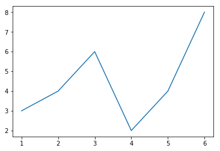

```python
import matplotlib.pyplot as plt

x = [1,2,3,4,5,6]
y = [3,4,6,2,4,8]

plt.plot(x, y)
```

## 函数

### 自定义函数

```python
def parity(n):
    """To judge whether an integer is odd or even."""      # the function help
    if n % 2 == 0:
        print(n,'是偶数',sep = '')
    elif n % 2 == 1:
        print(n,'是奇数',sep = '')
    else:
        print(n,'既不是奇数也不是偶数',sep = '')
```

```python
help(parity)
```

```
Help on function parity in module __main__:

parity(n)
    To judge whether an integer is odd or even.
```

```python
parity(3)
```

```
3是奇数
```

```python
parity(3.1)
```

```
3.1既不是奇数也不是偶数
```

匿名函数：关键字lambda表示匿名函数，冒号前面的x表示函数参数，后面只能有一个表达式，不用写return，返回值就是该表达式的结果。

```python
f = lambda x: x ** 2
f(2)
```

```
4
```

```python
def make_incrementor(n):
    return lambda x: x + n  #返回一个函数
```

```python
f = make_incrementor(42)
```

```python
f(0),f(1)
```

```
(42, 43)
```

汉诺塔问题：定义一个函数，接收参数n，表示3个柱子A、B、C中第1个柱子A的盘子数量，然后打印出把所有盘子从A借助B移动到C的方法

```python
def move(n, a, b, c):
    if n == 1:
            print(a, '-->', c)
    else:
        move(n-1, a, c, b)
        move(1, a, b, c)
        move(n-1, b, a, c)
```

```python
move(3, 'A', 'B', 'C')
```

```
A --> C
A --> B
C --> B
A --> C
B --> A
B --> C
A --> C
```

某些函数定义时设置了多个参数，使用默认参数可以简化该函数的调用：

```python
def power(x, n=2):  #幂函数
    s = 1
    while n > 0:
        s = s * x
        n = n - 1
    return s
```

```python
power(5) #只输入一个数，默认求其平方
```

```
25
```

```python
power(5,3)
```

```
125
```

functools.partial可以创建一个新的函数，这个新函数可以固定住原函数的部分参数，从而在调用时更简单

```python
import functools
int2 = functools.partial(int, base=2)
int2('1000000')     #相当于int('1000000',base = 2)，即默认二进制转换为十进制
```

```
64
```

### 生成器(generator)

如果一个函数定义中包含yield关键字，那么这个函数就不再是一个普通函数，而是一个generator,可通过for循环来迭代它

```python
def triangles(n):    #杨辉三角
    L = [1]
    for x in range(n):
        yield L
        L = [1] + [L[i] + L[i+1] for i in range(len(L)-1)] + [1]
```

```python
for x in triangles(10):
    print(x)
```

```
[1]
[1, 1]
[1, 2, 1]
[1, 3, 3, 1]
[1, 4, 6, 4, 1]
[1, 5, 10, 10, 5, 1]
[1, 6, 15, 20, 15, 6, 1]
[1, 7, 21, 35, 35, 21, 7, 1]
[1, 8, 28, 56, 70, 56, 28, 8, 1]
[1, 9, 36, 84, 126, 126, 84, 36, 9, 1]
```

### 高阶函数

变量可以指向函数,函数名也是变量,一个函数就可以接收另一个函数作为参数，这种函数就称之为高阶函数。

```python
def add(x, y, f):
    return f(x) + f(y)
```

```python
add(-5, 6, abs)
```

```
11
```

map(函数,可迭代序列)作为高阶函数，将传入的函数依次作用到序列的每个元素，并把结果作为新的迭代器返回。

```python
list(map(str, [1, 2, 3, 4, 5, 6, 7, 8, 9]))
```

```
['1', '2', '3', '4', '5', '6', '7', '8', '9']
```

```python
def normalize(name):  #将名字中的字母大小写规范化
    name = name.lower()
    name = name.capitalize()
    return name
```

```python
L = ['adam', 'LISA', 'barT']
list(map(normalize, L))
```

```
['Adam', 'Lisa', 'Bart']
```

reduce作为高阶函数，其效果是：reduce(f, [x1, x2, x3, x4]) = f(f(f(x1, x2), x3), x4) (f必须接收两个参数)

```python
from functools import reduce
def prod(L):  #求list中所有数的乘积
    return reduce(lambda x, y: x * y, L )
```

```python
prod([3, 5, 7, 9])
```

```
945
```

filter(函数，序列)：把传入的函数依次作用于每个元素，然后根据返回值是True还是False决定保留还是丢弃该元素。

```python
list(filter(lambda x: x % 2 == 1, [1, 2, 4, 5, 6, 9, 10, 15]))  #返回list中的奇数
```

```
[1, 5, 9, 15]
```

sorted(序列，keys)：按照keys中函数作用后的结果进行排序，并按照对应关系返回list相应的元素

```python
sorted([36, 5, -12, 9, -21], key=abs)
```

```
[5, 9, -12, -21, 36]
```

```python
students = [('Bob', 75), ('Adam', 92), ('Bart', 66), ('Lisa', 88)]

print(sorted(students, key=lambda x: x[0]))  #按名字
print(sorted(students, key=lambda x: x[1]))  #按成绩从低到高
print(sorted(students, key=lambda x: x[1], reverse=True))  #按成绩从高到低
```

```
[('Adam', 92), ('Bart', 66), ('Bob', 75), ('Lisa', 88)]
[('Bart', 66), ('Bob', 75), ('Lisa', 88), ('Adam', 92)]
[('Adam', 92), ('Lisa', 88), ('Bob', 75), ('Bart', 66)]
```

## Python 的类

面向对象的程序设计思想，是把对象作为程序的基本单元：类是抽象的模板，实例是根据类创建出来的一个个具体的“对象”，每个对象都拥有相同的方法，但各自的数据可能不同。

```python
class MyClass:
    """A simple example class"""
    i = 12345
    def f(self):
        return 'hello world'
```

```python
MyClass()
```

```
<__main__.MyClass at 0x4dedcf8>
```

```python
MyClass.i  #引用属性
```

```
12345
```

```python
MyClass.f
```

```
<function __main__.MyClass.f(self)>
```

```python
MyClass.i = 3  #更改属性值
MyClass.i
```

```
3
```

```python
MyClass.x = 1  #根据需要添加定义中没有的属性
MyClass.x
```

```
1
```

在创建实例的时候，定义一个特殊的**init**方法，把一些我们认为必须绑定的属性强制填写进去，可以起到模板的作用。

```python
class Complex:
    def __init__(self, realpart, imagpart):  #注意：特殊方法“__init__”前后分别有两个下划线
        self.r = realpart
        self.i = imagpart
```

```python
x = Complex(3.0, -4.5)
x.r, x.i
```

```
(3.0, -4.5)
```

## 读取文件

### 读取txt

```python
pwd
```

```
'C:\\Users\\Administrator\\Desktop'
```

在上述目录下创建一个test.txt,写入“Hello world！”

```python
file_for_reading = open('test.txt', 'r')  #‘r’表示read
```

```python
file_for_reading.read()
```

```
'Hello world! \n'
```

```python
file_for_reading.close()
```

```python
file_for_writing = open('test.txt', 'w')  #‘w’表示write
```

```python
file_for_writing.write('I love studying! \n')
```

```
18
```

```python
file_for_writing.close()
```

查看test.txt，发现内容变成了‘I love studying!’，说明原内容被覆盖

```python
file_for_appending = open('test.txt','a') #‘a’表示append
```

```python
file_for_appending.write('Hello world! \n')
```

```
14
```

```python
file_for_appending.close()
```

再次查看，发现原内容后加入了一行Hello world!

由于close()很容易忘记，故推荐采用with语句，在语句执行完毕后自动关闭：

```python
with open('test.txt','a') as file:
    file.write('Nice to meet you! \n')
```

### 读取csv

在工作目录下创建一个stocks.csv,由symbol,date,closing_price三列构成，并填充数据

```python
import csv

data = {'symbol':[], 'date':[], 'closing_price' : []}
with open('stocks.csv', 'r') as f:
    reader = csv.DictReader(f)
    for row in reader:
        data['symbol'].append(row["symbol"])
        data['date'].append(row["date"])
        data['closing_price'].append(float(row["closing_price"]))
```

```python
data.keys()
```

```
dict_keys(['symbol', 'date', 'closing_price'])
```

```python
data['closing_price']
```

```
[112.98, 112.4, 109.55, 108.72, 105.99]
```

也可使用pandas包中的read_csv()函数读取csv文件：

```python
import pandas
data2 = pandas.read_csv('stocks.csv')
print(len(data2))
print(type(data2))
```

```
5
<class 'pandas.core.frame.DataFrame'>
```

```python
data2
```

|  | symbol | date | closing_price |
| --- | --- | --- | --- |
| 0 | AAPL | 2015/1/23 | 112.98 |
| 1 | AAPL | 2015/1/22 | 112.40 |
| 2 | AAPL | 2015/1/21 | 109.55 |
| 3 | AAPL | 2015/1/20 | 108.72 |
| 4 | AAPL | 2015/1/16 | 105.99 |

```python
data2.iloc[1]
```

```
symbol                AAPL
date             2015/1/22
closing_price        112.4
Name: 1, dtype: object
```

```python
data2.iloc[1]['date']
```

```
'2015/1/22'
```

## 文本处理

```python
import nltk
```

```python
nltk.download('punkt')
```

```
True
```

分段为句：

```python
para = "Python is a widely used general-purpose, high-level programming language. Its design philosophy emphasizes code readability, and its syntax allows programmers to express concepts in fewer lines of code than would be possible in languages such as C++ or Java."
```

```python
from nltk.tokenize import sent_tokenize
sent_tokenize(para)
```

```
['Python is a widely used general-purpose, high-level programming language.',
 'Its design philosophy emphasizes code readability, and its syntax allows programmers to express concepts in fewer lines of code than would be possible in languages such as C++ or Java.']
```

分段为词：

```python
from nltk.tokenize import word_tokenize
word_tokenize(para)
```

```
['Python',
 'is',
 'a',
 'widely',
 'used',
 'general-purpose',
 ',',
 'high-level',
 'programming',
 'language',
 '.',
 'Its',
 'design',
 'philosophy',
 'emphasizes',
 'code',
 'readability',
 ',',
 'and',
 'its',
 'syntax',
 'allows',
 'programmers',
 'to',
 'express',
 'concepts',
 'in',
 'fewer',
 'lines',
 'of',
 'code',
 'than',
 'would',
 'be',
 'possible',
 'in',
 'languages',
 'such',
 'as',
 'C++',
 'or',
 'Java',
 '.']
```

过滤掉语句中的“stopwords”：

```python
nltk.download('stopwords')
```

```
True
```

```python
from nltk.corpus import stopwords
english_stops = set(stopwords.words('english'))
print(english_stops)  #输出stopwords
```

```
{'which', "hadn't", 'can', 'but', 'whom', 'won', 'too', 'under', 'more', 'to', 'that', 't', 'theirs', 'doing', 'your', 'those', 'up', 'doesn', 'again', 'hadn', 'mustn', 'an', 'in', 'didn', 'same', 'been', 'of', 'most', 'as', 'where', 'once', 'o', 'own', 'off', 'ain', 'hasn', 'no', 'during', 'all', '…
```

```python
from nltk.tokenize import RegexpTokenizer
tokenizer = RegexpTokenizer("[\w']+")
words = tokenizer.tokenize("Smoking is now banned in many places of work.")
words
```

```
['Smoking', 'is', 'now', 'banned', 'in', 'many', 'places', 'of', 'work']
```

```python
[word for word in words if word not in english_stops]
```

```
['Smoking', 'banned', 'many', 'places', 'work']
```

去掉词缀：

```python
from nltk.stem import PorterStemmer
stemmer = PorterStemmer()
stemmer.stem('cooking')
```

```
'cook'
```

## 网络爬虫

网络爬虫（Web crawler），是一种按照一定的规则，自动地抓取万维网信息的程序或者脚本，它们被广泛用于互联网搜索引擎或其他类似网站，可以自动采集所有其能够访问到的页面内容，以获取或更新这些网站的内容和检索方式。从功能上来讲，爬虫一般分为数据采集，处理，储存三个部分。

使用Python这样的简单编程语言，你可以使用少量编程技能就可以爬取复杂的网站。

查看源文件的方法：1.在要爬取的页面上点击鼠标右键 2.用如下方式：

```python
from urllib.request import urlopen
html = urlopen('https://feng.li/python/')
print(html.read())
```

```
b'<!DOCTYPE html>\n<html lang="en-US" class="no-js">\n<head>\n\t<meta charset="UTF-8">\n\t<meta name="viewport" content="width=device-width, initial-scale=1">\n\t<link rel="profile" href="http://gmpg.org/xfn/11">\n\t\t<script>(function(html){html.className = html.className.replace(/\\bno-js\\b/,\'js…
```

从上面输出的源文件不能清楚地看出网页所表达的内容，下面我们用BeautifulSoup库来爬取网页：

```python
from urllib.request import urlopen
from bs4 import BeautifulSoup
#使用BeautifulSoup解析,能够得到一个 BeautifulSoup 的对象,并能按照标准的缩进格式的结构输出

html = urlopen('https://feng.li/python/')
bs = BeautifulSoup(html.read(), 'html.parser') #html.parser是Python默认的解析器
print(bs)
```

[output not shown]

[output cut: 343 more lines]

[output not shown]

下面筛选出我们想要的内容：

find( name , attrs , recursive , text , **kwargs )

find() 方法搜索当前标签的所有子节点,并判断是否符合过滤器的条件

```python
from urllib.request import urlopen
from bs4 import BeautifulSoup

html = urlopen('https://feng.li/python/')
bs = BeautifulSoup(html.read(), 'html.parser')

#<div>标签可以把文档分割为独立的、不同的部分，通过 find() 方法的 attrs 参数定义一个字典参数来搜索包含特殊属性的标签
name = bs.find('div', {'class':'entry-content'})
print(name.get_text())
```

```
This page serves as the primary guide for my students who want to learn Python.
```

find_all( name , attrs , recursive , text , **kwargs )

它与 find() 方法唯一的区别是:find_all() 方法的返回结果是值包含一个元素的列表,而 find() 方法直接返回结果

```python
nameList = bs.find_all('div', {'class':'entry-content'})
for name in nameList:
    print(name.get_text())
```

```
This page serves as the primary guide for my students who want to learn Python.
```

```python
print(bs.title) #通过这种bs.标签名的方式,获得这个标签的内容  注:查找的是在所有内容中的第一个符合要求的标签
```

```
<title>Python – Dr. Feng Li</title>
```

```python
print(bs.title.string)  #获取标签内部的文字
```

```
Python – Dr. Feng Li
```

用BeautifulSoup中的select方法可以获取相应的元素，且获取的元素为list形式

```python
print(bs.select('title')) #通过标签名筛选元素
```

```
[<title>Python – Dr. Feng Li</title>]
```

```python
print(bs.select('.entry-content')) #通过类名查找,类名前加点
```

```
[<div class="entry-content">
<p>This page serves as the primary guide for my students who want to learn Python.</p>
</div>]
```

```python
print(bs.select('.entry-content p')) #组合查找：某一类下的某个标签中的内容，采用空格隔开：
```

```
[<p>This page serves as the primary guide for my students who want to learn Python.</p>]
```

```python
print(bs.select('#media_image-2')) #通过id名查找,id名前加#
```

```
[<section class="widget widget_media_image" id="media_image-2"><figure class="wp-caption alignnone" style="width: 800px"><a href="http://feng.li"><img alt="" class="image roundborder" height="800" src="/files/style/Portrait-Small.png" width="800"/></a><figcaption class="wp-caption-text">Dr. Feng Li …
```

利用上述方法我们来爬取一则新浪新闻，并将结果导出到excel：

```python
from urllib.request import urlopen
from bs4 import BeautifulSoup
import pandas

#创建BeautifulSoup对象
html = urlopen('http://news.sina.com.cn/o/2018-11-12/doc-ihnstwwr2055624.shtml')
soup = BeautifulSoup(html.read(), 'html.parser')
```

```python
#获取标题
newstitle = soup.select('.main-title')[0].text.strip()
# 获取新闻内容
article = []
for p in soup.select('.article p'):
    if p.text.strip() != '':
          article.append(p.text.strip())
article = ' '.join(article)  #将article列表内容合并到一起，用空格作分隔
# 获取出版时间
newstime = soup.select('.date')[0].text.strip()
#获取新闻来源
source = soup.select('.source')[0].text.strip()
```

```python
#整合
total = {'title':newstitle,'article':[article],'time':newstime,'source':source}
#输出到excel
df = pandas.DataFrame(total)
df.to_excel('news.xlsx')
```

如果需要导入多则新闻信息到excel，可使用for循环。

效果图：https://images2017.cnblogs.com/blog/1106936/201707/1106936-20170729214309378-36314622.jpg